# Regression

Martin Sigrist (21-101-175)

03.06.2023

# Introduction

The aim of this chapter is stepwise forward regression. The dependent variable is the gross primary production (GPP). It is defined a the gross CO<sub>2</sub> uptake flux driven by photosynthesis.

The used data is from the Fluxnet from the Davos site (https://fluxnet.org/sites/siteinfo/CH-Dav). The following variables are considered in for the evaluation:

- TA_* (°C): Air temperature
- SW_IN_* (W m<sup>−2</sup>): Shortwave incoming radiation
- LW_IN_* (W m<sup>−2</sup>): Longwave incoming radiation
- VPD_* (hPa): Vapor pressure deficit (the difference between actual and saturation water vapor pressure)
- PA_* (kPa): Atmospheric pressure
- P_* (mm): Precipitation
- WS_* (m s<sup>−1</sup>): Wind speed
- CO2_* (µmolCO<sub>2</sub> mol<sup>−1</sup>): Carbon Dioxide (CO<sub>2</sub>) mole fraction in moist air
- PPFD_IN (µmolPhotons m<sup>−2</sup> s<sup>−1</sup>): incoming photosynthetic photon flux density
- GPP_* (μmol<sub>CO2</sub> m<sup>−2</sup> s<sup>−1</sup>): Gross primary production (the ecosystem-level gross CO2 uptake flux driven by photosynthesis)

# Load required libraries

```r
library(tidyverse)
```

# Load data

```r
half_hourly_fluxes <- read_csv("../data/df_for_stepwise_regression.csv", show_col_types = FALSE)
```

# Bivariate Models

In a first step, a bivariate model for each independent variable is calculated

```r
# Vector with names of independent variables
indep_vars <- colnames(half_hourly_fluxes)[! colnames(half_hourly_fluxes) %in% c("siteid", "TIMESTAMP", "GPP_NT_VUT_REF")]

# Create empty variable for results
res <- NULL

for (i in indep_vars) {
  # Calculate linear model
  linmod <- lm(as.formula(paste("GPP_NT_VUT_REF ~ ", i)), data = half_hourly_fluxes)

  # Add results for actual model to result data frame
  res <- bind_rows(res,
                   tibble(
                     feature = i,
                     mse = mean(linmod$residuals^2),
                     R2 = summary(linmod)$r.squared,
                     R2_adj = summary(linmod)$adj.r.s,
                     AIC = extractAIC(linmod)[2],
                     BIC = BIC(linmod))) # this implementation is based on log-likelihood
}

# Show results, rounded on three decimal places
res |> mutate_at(vars(-feature), ~round(., 3)) |>
  knitr::kable(format = "html") |>
  kableExtra::kable_classic(full_width = F)
```

| feature | mse | R2 | R2_adj | AIC | BIC |
| --- | --- | --- | --- | --- | --- |
| TA_F | 6.217 | 0.387 | 0.387 | 37619.26 | 96062.76 |
| SW_IN_F | 5.776 | 0.431 | 0.431 | 36102.41 | 94545.91 |
| LW_IN_F | 8.444 | 0.168 | 0.168 | 43919.98 | 102363.47 |
| VPD_F | 8.208 | 0.191 | 0.191 | 43337.05 | 101780.54 |
| PA_F | 10.141 | 0.000 | 0.000 | 47691.83 | 106135.32 |
| P_F | 10.123 | 0.002 | 0.002 | 47653.72 | 106097.22 |
| WS_F | 10.060 | 0.008 | 0.008 | 47526.24 | 105969.74 |
| TA_F_MDS | 6.212 | 0.387 | 0.387 | 37559.45 | 95934.83 |
| SW_IN_F_MDS | 5.777 | 0.430 | 0.430 | 36065.75 | 94443.97 |
| LW_IN_F_MDS | 9.562 | 0.121 | 0.121 | 25130.95 | 56737.63 |
| VPD_F_MDS | 8.287 | 0.181 | 0.181 | 42567.59 | 99714.11 |
| CO2_F_MDS | 9.844 | 0.030 | 0.030 | 47078.99 | 105522.48 |
| PPFD_IN | 5.808 | 0.452 | 0.452 | 29689.54 | 77601.07 |
| USTAR | 10.179 | 0.000 | 0.000 | 45048.57 | 100165.90 |

## Scatter plots

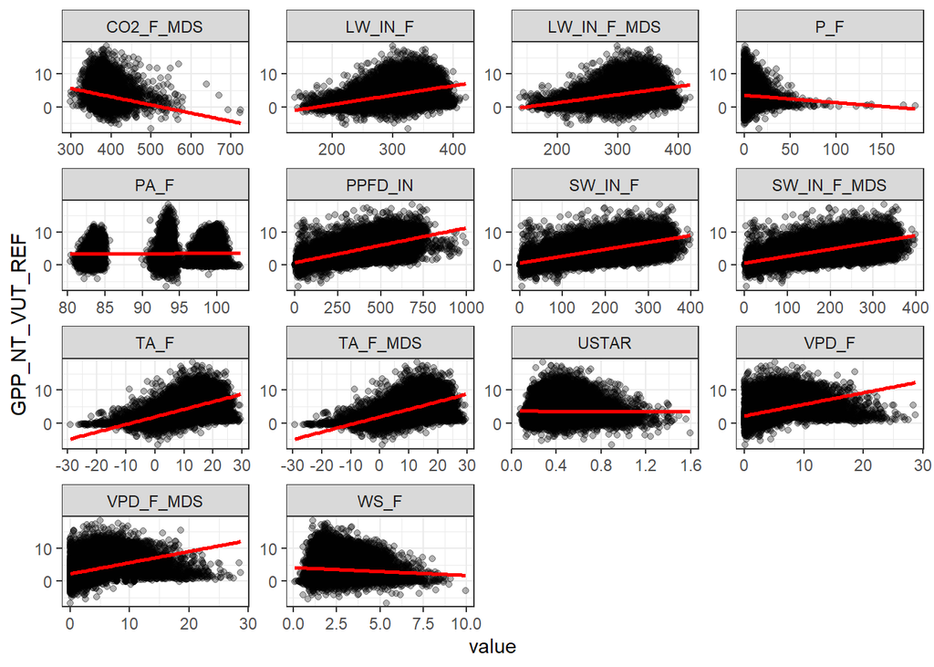

```r
# Create scatter plots for each independent variable
half_hourly_fluxes |>
  select_if(is.numeric) |>
  gather(-GPP_NT_VUT_REF, key = "var", value = "value") |>
  drop_na() |>
  ggplot(aes(x = value, y = GPP_NT_VUT_REF)) +
    geom_point(alpha = 0.3) +
    stat_smooth(formula = y ~ x, method = "lm", color = "red", se = FALSE) +
    facet_wrap(~ var, scales = "free") +
    theme_bw()
```

## Discussion

R<sup>2</sup> reaches the highest values in the bimodal linear regressions for the air temperature (TA_F, TA_F_MDS), the incoming short wave radiation (SW_IN_F, SW_IN_F_MDS) and the incoming photosynthetic photon flux density (PPFD_IN). Variables with the same name but with different suffixes (_F, _F_MDS) are principally the same measurement, but for the first, gaps are filled by Marginal Distribution Sampling (MDS) (Pastorello et al. 2020). The resulting values for each variable pair are therefore very similar. The determination coefficient and the mean square error for the PPFD_IN variable are similar to them of the short wave radiation. The photosynthetically active radiation is part of the total incoming radiation. Similar results are expected and observed.

# Stepwise forward regression

In the second part, a linear model is compiled stepwise. For each step, one more independent variable is added to the model until the Akaike’s Information Criterion (AIC) reaches a minimal value.

```r
# Vector with names of independent variables
indep_vars <- colnames(half_hourly_fluxes)[! colnames(half_hourly_fluxes) %in% c("siteid", "TIMESTAMP", "GPP_NT_VUT_REF")]

# Create empty data frame for results
df_res <- data.frame(matrix(nrow = 0, ncol = length(indep_vars) + 2))
#provide column names
colnames(df_res) <- append(append(c("base.model"), indep_vars),"AIC")

model_vars <- NULL # Define empty variable for the independent variables of the actual model
step_AIC <- NULL # Variable to store AIC value for the highest R2 in the sctual step

n_step <- 0 # Variable for if condition in the repeat-loop to avoid index problems

repeat { # Loop to go through the independent variables
  max_R2 <- 0 # Variable to store the highest R2 for the actual step

  # Add new row to result data frame
  df_res[nrow(df_res)+1,] <- rep(NA, 16) # Fill new row with N/As
  df_res[nrow(df_res),1] <- paste(model_vars, collapse=" + ") # Fill first cell in new row with the previous model formulation


  for (i in indep_vars) { # Loop to go though the remaining variables, not yet in the model
    # Calculate linear model (Remove all N/As to become comperable with the result from the step function, that only works without N/As)
    linmod <- lm(as.formula(paste("GPP_NT_VUT_REF ~ ", paste(append(model_vars, i), collapse=" + "))), data = half_hourly_fluxes |> drop_na())

    # Store actual predictor, AIC and R2 if R2 is the highest in the actual round
    if(summary(linmod)$r.squared > max_R2) {
      max_R2 <- summary(linmod)$r.squared
      step_AIC <- extractAIC(linmod)[2]
      best_predictor <- i
    }

    # Add R2 for the actual variable to the result data frame
    df_res[nrow(df_res),i] <- summary(linmod)$r.squared
  }

  # Add best predictor for the actual step to model
  model_vars <- append(model_vars, best_predictor)

  # Add AIC for the highest R2 in the actual step to the result data frame
  df_res[nrow(df_res),"AIC"] <- step_AIC

  # Remove best predictor from actual round from overall list of independent variables
  indep_vars <- indep_vars[!indep_vars %in% best_predictor]


  if(step_AIC > df_res[nrow(df_res)-n_step,"AIC"]) { # Break condition for repeat loop
    break
  }
  n_step <- 1
}

# Print best model
cat("Best model: ", paste("GPP_NT_VUT_REF ~ ", df_res[nrow(df_res),1]), "\n")
```

```
## Best model:  GPP_NT_VUT_REF ~  PPFD_IN + LW_IN_F + VPD_F + TA_F_MDS + WS_F + USTAR + SW_IN_F + P_F + CO2_F_MDS + PA_F
```

```r
cat("R2 for best model: ", max(df_res[nrow(df_res)-1,3:ncol(df_res)-1], na.rm = TRUE), "\n")
```

```
## R2 for best model:  0.528666
```

```r
cat("AIC for best model: ", df_res[nrow(df_res)-1,ncol(df_res)], "\n")
```

```
## AIC for best model:  15893.35
```

## Results Visualisation

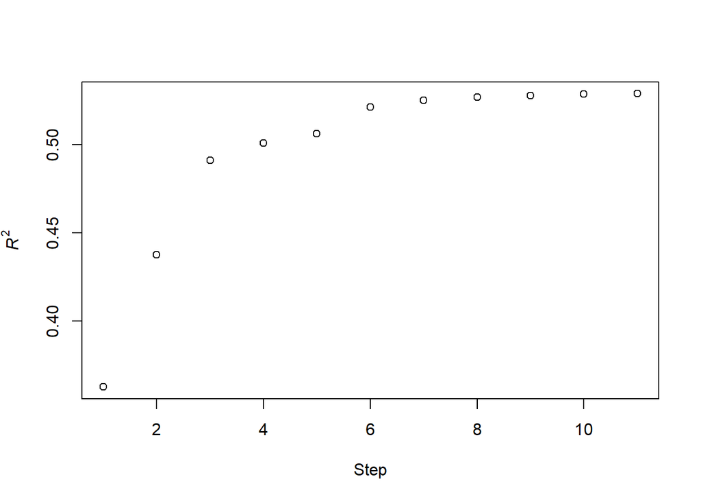

```r
plot(apply(df_res[,3:ncol(df_res)-1], 1, max, na.rm = TRUE),
     xlab = "Step",
     ylab = bquote(italic(R)^2),) # Max value of Coefficient of determination for each step
```

Plotting R<sup>2</sup> against each step of the stepwise forward regression shows its convergence.

# Using step-funtcion from stats-library

```r
# Generate scope model for the stepwise forward regression function "step"
scope_model <- paste("GPP_NT_VUT_REF ~ ", paste(colnames(half_hourly_fluxes)[! colnames(half_hourly_fluxes) %in% c("siteid", "TIMESTAMP", "GPP_NT_VUT_REF")], collapse=" + "))

stats::step(
  object = lm(GPP_NT_VUT_REF ~ 1, # Start with the simplest model with only a consant
                data = half_hourly_fluxes |> select(-siteid, -TIMESTAMP)|> drop_na() # Remove all NA to make the step function work
              ),
  scope = scope_model, # Scope model, including all variables
  direction = "forward"
)
```

```
## Start:  AIC=23014.62
## GPP_NT_VUT_REF ~ 1
##
##               Df Sum of Sq    RSS   AIC
## + PPFD_IN      1     38886  68301 18738
## + SW_IN_F_MDS  1     37560  69627 18921
## + SW_IN_F      1     37550  69636 18922
## + TA_F_MDS     1     29652  77534 19942
## + TA_F         1     29651  77536 19942
## + VPD_F        1     12645  94542 21825
## + LW_IN_F_MDS  1     12473  94713 21842
## + LW_IN_F      1     12247  94940 21865
## + VPD_F_MDS    1     11952  95234 21894
## + CO2_F_MDS    1      5373 101814 22528
## + WS_F         1      1318 105869 22899
## + P_F          1       318 106869 22988
## + PA_F         1        31 107156 23014
## <none>                     107187 23015
## + USTAR        1         3 107183 23016
##
## Step:  AIC=18738.19
## GPP_NT_VUT_REF ~ PPFD_IN
##
##               Df Sum of Sq   RSS   AIC
## + LW_IN_F      1    8002.7 60298 17557
## + LW_IN_F_MDS  1    7890.7 60410 17575
## + TA_F_MDS     1    3518.7 64782 18238
## + TA_F         1    3518.3 64783 18238
## + VPD_F_MDS    1    3000.9 65300 18314
## + VPD_F        1    2910.4 65391 18327
## + P_F          1     849.5 67452 18621
## + WS_F         1     326.9 67974 18695
## + PA_F         1      90.5 68211 18728
## + CO2_F_MDS    1      40.3 68261 18735
## + USTAR        1      14.9 68286 18738
## <none>                     68301 18738
## + SW_IN_F      1       2.5 68299 18740
## + SW_IN_F_MDS  1       2.3 68299 18740
##
## Step:  AIC=17557.04
```

[output cut: 114 more lines]

```
## + LW_IN_F_MDS  1     7.324 50617 15911
## + TA_F         1     4.365 50620 15912
## + SW_IN_F_MDS  1     0.164 50624 15913
## + VPD_F_MDS    1     0.099 50624 15913
##
## Step:  AIC=15893.35
## GPP_NT_VUT_REF ~ PPFD_IN + LW_IN_F + VPD_F + TA_F_MDS + WS_F +
##     USTAR + SW_IN_F + P_F + CO2_F_MDS + PA_F
##
##               Df Sum of Sq   RSS   AIC
## <none>                     50521 15893
## + LW_IN_F_MDS  1    4.7788 50516 15894
## + TA_F         1    4.4312 50516 15894
## + VPD_F_MDS    1    1.9423 50519 15895
## + SW_IN_F_MDS  1    0.0190 50521 15895
```

```
##
## Call:
## lm(formula = GPP_NT_VUT_REF ~ PPFD_IN + LW_IN_F + VPD_F + TA_F_MDS +
##     WS_F + USTAR + SW_IN_F + P_F + CO2_F_MDS + PA_F, data = drop_na(select(half_hourly_fluxes,
##     -siteid, -TIMESTAMP)))
##
## Coefficients:
## (Intercept)      PPFD_IN      LW_IN_F        VPD_F     TA_F_MDS         WS_F
##   -3.622482     0.006721     0.016821    -0.393928     0.096008    -0.926851
##       USTAR      SW_IN_F          P_F    CO2_F_MDS         PA_F
##    4.584353     0.011264    -0.021003    -0.005021     0.020922
```

# Discussion

The stepwise forward regression algorithm is working. The implementation would accept also a different number of independent variables. Future improvements for an increased efficiency might be possible. The computational effort was not a scope of this work, as the amount of data to be processed is kept rather low. The step-function from the stats-library gives the same results for the final linear model, R<sup>2</sup> and AIC.

In the final model, from the two temperature variables (TA_F and TA_F_MDS) and the two incoming short wave radiation (SW_IN_F and SW_IN_F_MDS) are only one present. Because two of each represent the same measurements, they are not linear independent and adding the second one would not improve the model. A similar effect is observed between the PPFD_IN and the SW_IN_F variables. In the bivariate models, they both had a similar determination coefficient. But the wave length spectrum covered by the PPFD_IN variable is part of the wave length spectrum of the SW_IN_F variable and they are not fully independent. Therefore, the addition of the second one to the model has only a small positive effect on the determination coefficient.

# Literature

Pastorello, Gilberto, et al. 2020: The FLUXNET2015 dataset and the ONEFlux processing pipeline for eddy covariance data. Scientific Data 7 (1): 225. DOI: https://doi.org/10.1038/s41597-020-0534-3